# CMSC320 Final Project

Eric

April 10, 2018

We will be analyzing how effective the video game Out of the Park (OOTP) is at simulating a baseball season. To do this, I have ran a simulation in the game from the years 2000 to 2018. The game has a built-in feature where it will export many of it’s important data files to a CSV file with headers on top, allowing for us to easily load the game data into an R dataframe. We will use the Lahman sqlite database as the point of comparison.

First, we will load the CSV files and connect to the Lahman database.

```r
library(rvest)
library(tidyverse)
```

```r
coaches <- read.csv('csv/coaches.csv')
divisions <- read.csv('csv/divisions.csv')
leagues <- read.csv('csv/leagues.csv')
allstars <- read.csv('csv/league_history_all_star.csv')
players <- read.csv('csv/players.csv')
awards <- read.csv('csv/league_history.csv')
batting_stats <- read.csv('csv/players_career_batting_stats.csv')
pitching_stats <- read.csv('csv/players_career_pitching_stats.csv')
teams <- read.csv('csv/teams.csv')
team_history_record <- read.csv('csv/team_history_record.csv')
team_history_financials <- read.csv('csv/team_history_financials.csv')

lahman <- DBI::dbConnect(RSQLite::SQLite(), "lahman2016.sqlite")
```

# About The Dataframes

For files about players the primary key will be player_id. For files about a team, the primary key will be team_id. There are other variables that we can use to help pinpoint what we are searching for. For player stats, there are various unhelpful stats saved such as pre-season and play-off stats. Thanks to the variable split_id, any entity that has a value 1 in this column is a regular season batting line, which is what we are looking for. The attribute year will also be usefull throughout for zero-ing in on a single year and for performing year-to-year analysis.

Linked here is a Wikipedia article: [https://en.wikipedia.org/wiki/Baseball_statistics][1]

# Data Analysis

First, let’s see how the simulated hit total compares to the real-life values. We will look at the residual for each year for each player with atleast 50 hits in both the simulation and real-life for a given season. This will eliminated players that did not play as many games as expected and also removes pitchers.

```sql
select nameFirst as first_name, nameLast as last_name, H as hits, yearID as year_id
from MASTER, Batting
where MASTER.playerID = Batting.playerID and yearID >= 2000 and H > 50
group by nameFirst, nameLast, yearID
```

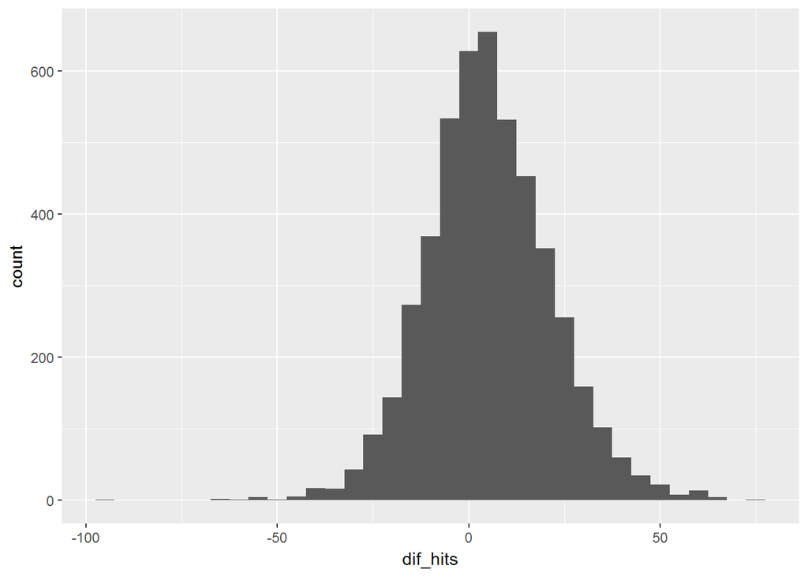

```r
library(ggplot2)

hits_by_year <- players %>% inner_join(batting_stats, by = 'player_id') %>%
  filter(split_id == 1,h > 50) %>% select(player_id,first_name, last_name, sim_hits = h ,year_id = year)

hits_difference <- hits_by_year %>% inner_join(lahman_hits, on = c('first_name', 'last_name', 'year_id'))
hits_difference['dif_hits'] <- hits_difference['sim_hits'] - hits_difference['hits']

hits_difference %>% ggplot(mapping=aes(x=dif_hits)) + geom_histogram(binwidth = 5)
```

Looking at the above histogram of the residuals, the simulation is quite good at simulating how many hits a player will get. The histogram is slightly skewed to the right, which indicates that was a slight tendency to simulate more hits than a player actually got.

Next lets look at how well the game simulated each season by computing their average positioning in their division

```sql
select avg(Rank) as real_pos, name, teamID, franchID
from Teams
where yearID >= 2000
group by teamID
```

```r
sim_pos <- team_history_record %>% inner_join(teams, by = 'team_id') %>%
  select(team_id,historical_id, pos, year) %>% group_by(historical_id) %>% summarize(sim_pos=mean(pos))

diff_pos <- sim_pos %>% inner_join(lahman_pos, by = c("historical_id"="teamID"))
diff_pos['diff'] <- - diff_pos$sim_pos + diff_pos$real_pos

diff_pos %>% select(diff,historical_id) %>% arrange(desc(diff))
```

```
## # A tibble: 30 x 2
##      diff historical_id
##     <dbl> <chr>
##  1 1.72   MIA
##  2 0.859  PIT
##  3 0.794  TOR
##  4 0.755  CHN
##  5 0.716  COL
##  6 0.484  CLE
##  7 0.268  KCA
##  8 0.252  BOS
##  9 0.206  TEX
## 10 0.0915 BAL
## # ... with 20 more rows
```

```r
diff_pos %>% summarize(sd=sd(diff), mean=mean(diff))
```

```
## # A tibble: 1 x 2
##      sd     mean
##   <dbl>    <dbl>
## 1 0.563 -0.00120
```

Above we have the differences between divisional placings. We can see that MIA was the best performer relative to their actual standings. MIA is a considerable outlier here. With a mean of essentially zero and SD of about .56, MIA is over 3 SDs away. No other team is over 2 SDs away!

Next, let’s look at what awards were won and by who. First we will look at who won the MVP in both the AL and NL

```r
sim_awards <- awards %>% inner_join(players, by = c("best_hitter_id" = "player_id"))
sim_awards$league <- ifelse(sim_awards$sub_league_id == 0, 'AL', 'NL')

sim_awards %>% select(first_name, last_name, league, year)
```

```
##    first_name   last_name league year
## 1     Pedro J    Martinez     AL 2000
## 2        Todd      Helton     NL 2000
## 3         Jim       Thome     AL 2001
## 4        Todd      Helton     NL 2001
## 5     Pedro J    Martinez     AL 2002
## 6      Albert      Pujols     NL 2002
## 7     Pedro J    Martinez     AL 2003
## 8      Albert      Pujols     NL 2003
## 9       Johan     Santana     AL 2004
## 10     Albert      Pujols     NL 2004
## 11       Alex   Rodriguez     AL 2005
## 12     Albert      Pujols     NL 2005
## 13      David       Ortiz     AL 2006
## 14     Miguel     Cabrera     NL 2006
```

[output cut: 22 more lines]

There are quite a few pitchers winning the MVP. As we can see below, there were 10 instances of pitchers winning MVP! This is obviously too much. In real life, the only pitchers to accomplish this from 2000-2016 were Justin Verlander and Clayton Kershaw. In history there has only been around a dozen, so having close to that total in a 17 year simulation is a clear fault.

```r
print (sim_awards %>% left_join(pitching_stats, by = c("best_hitter_id" = "player_id", "year" = "year")) %>% filter(split_id == 1) %>% select(first_name, last_name) %>% nrow())
```

```
## [1] 10
```

We will now create a data frame for batting stats with all the useless variables excluded.

```r
trimed_batting_stats <- players %>% left_join (batting_stats, by=c('player_id'='player_id'))  %>% filter (split_id == 1) %>% filter(position.x != 1) %>% select(year, player_id, first_name, last_name, ab, h, k ,pa, d, t, hr, r, rbi, sb, cs, bb, ibb) %>% filter(ab!=0)
```

We now have all the counting stats that we will need. However, it would be beneficial to include some rate statistics along with these counting stats. We will use:

BA -> h/ab OBP -> (h+bb+ibb)/(ab+bb+ibb) SLG -> h+d+2t+3hr HR% -> hr/ab BB% -> bb+ibb/pa K% -> k/pa ISO -> SLG-BA

```r
trimed_batting_stats <- trimed_batting_stats %>% mutate(BA=h/ab, OBP=(h+bb+ibb)/(ab+bb+ibb), SLG=(h+d+2*t+3*hr)/ab, HRpercent=hr/ab, BBpercent=(bb+ibb)/pa, Kpercent=k/pa)
trimed_batting_stats <- trimed_batting_stats %>% mutate(ISO=SLG-BA)
```

Let’s look at who had some of the best rate stats in the simulation. Who had the best single season homerun-rate, given that they had atleast 300 at-bats?

```r
trimed_batting_stats %>% arrange(desc(HRpercent)) %>% filter (ab > 300) %>% slice(1:10) %>% select(year,first_name,last_name, HRpercent, hr)
```

```
## # A tibble: 10 x 5
##     year first_name last_name HRpercent    hr
##    <int> <fct>      <fct>         <dbl> <int>
##  1  2000 Larry      Walker       0.115     44
##  2  2000 Barry      Bonds        0.113     59
##  3  2006 Adam       Dunn         0.113     65
##  4  2003 Sammy      Sosa         0.103     55
##  5  2006 Ryan       Howard       0.103     63
##  6  2003 Barry      Bonds        0.103     49
##  7  2017 Manny      Machado      0.0988    67
##  8  2001 Jim        Thome        0.0972    52
##  9  2012 Jose A     Bautista     0.0967    35
## 10  2009 Adam       Dunn         0.0955    55
```

It seems that in 2000 pitchers enjoyed giving up homeruns, as the two top seasons came from the 2000 season.

Who averaged the most runs batted in?

```r
trimed_batting_stats %>% group_by(first_name, last_name) %>% summarize(avg_rbi = mean(rbi), num_years = n()) %>% arrange(desc(avg_rbi)) %>% head(n=10)
```

```
## # A tibble: 10 x 4
## # Groups:   first_name [9]
##    first_name last_name avg_rbi num_years
##    <fct>      <fct>       <dbl>     <int>
##  1 Nolan      Arenado     121           5
##  2 Albert     Pujols      116          17
##  3 Miguel     Cabrera     115          15
##  4 Carlos     Delgado     112          10
##  5 Vladimir   Guerrero    109          12
##  6 Alex       Rodriguez   105          16
##  7 Albert     Belle       105           1
##  8 Kris       Bryant      102           3
##  9 Sammy      Sosa         98.0         7
## 10 Robinson   Cano         97.4        13
```

Continuing playing with the homerun totals, let’s graph how many homeruns were hit in each year.

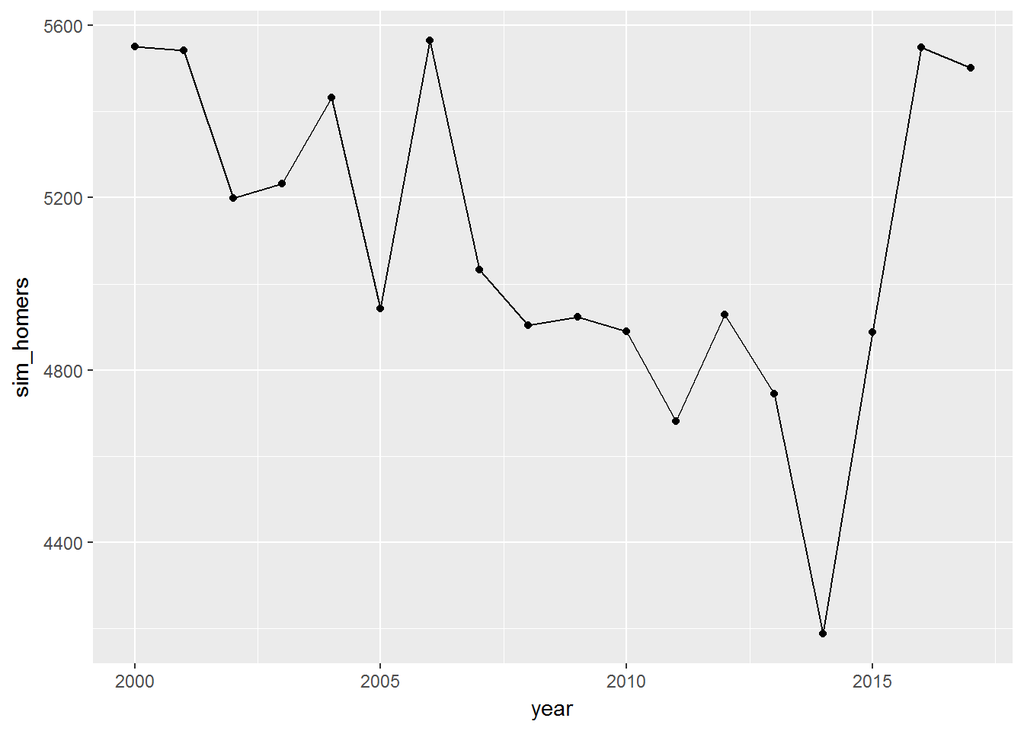

```r
homers_by_year <- batting_stats %>% filter(split_id == 1) %>% group_by(year) %>% summarize(sim_homers=sum(hr))

homers_by_year %>% ggplot(mapping=aes(x=year,y=sim_homers)) + geom_point() + geom_line()
```

This graph seems to follow the true to life patterns of the steroid era and the flyball era. Let’s compare this tothe realife values to see how it does.

```sql
select sum(HR) as actual_homers, yearID
from Teams
where yearID >= 2000
group by yearID
```

We will now join these two data frames together.

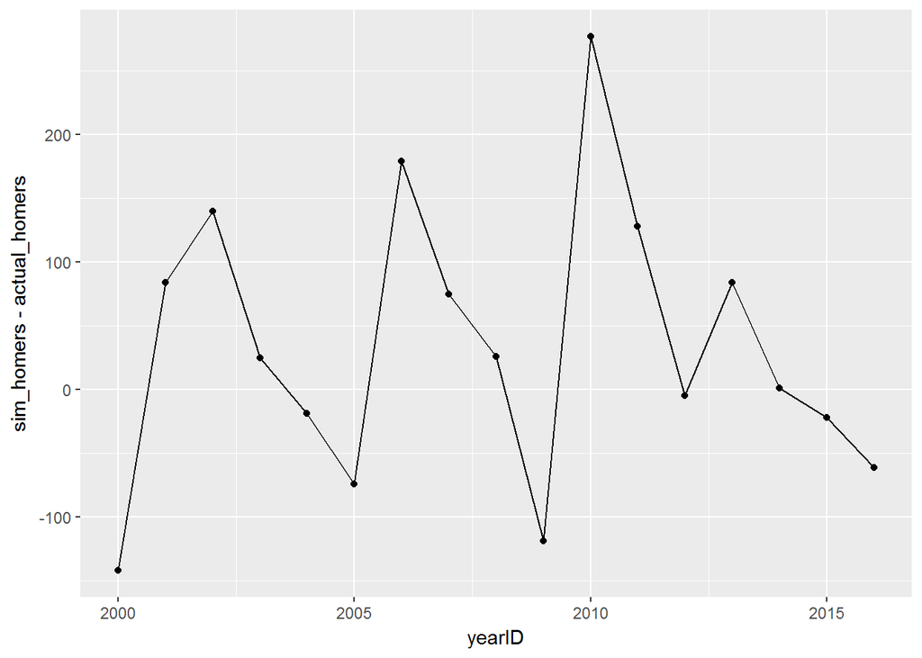

```r
sim_and_real_hr_totals <- lahman_hr %>% left_join(homers_by_year, by=c('yearID'='year'))

sim_and_real_hr_totals %>% ggplot(mapping=aes(x=yearID,y=sim_homers-actual_homers)) + geom_point() + geom_line()
```

```r
(sim_and_real_hr_totals$sim_homers-sim_and_real_hr_totals$actual_homers) %>% abs() %>% mean()
```

```
## [1] 85.94118
```

The game again did a good job! As calculated above, the simulation was off by 85 homers on average for each year. While this might seem like a lot, when we consider this is spread over 30 teams, that’s less than 3 homers per team that the game was off by!

# Modeling and Prediction

Now, let’s do something a little more interesting. Let’s build a model to predict if a player has had an All-star caliber season. We can do this as we have the data for who was on the all-star team. We can therefore create a binary variable for is a player was an all-star. We can then train it on various stats to see what is the best set of statistics to train on. We will only worry about hitters with this model.

The trimed dataset we made earlier will be helpful for this. Let’s first look at the all-star dataframe

```r
allstars
```

```
##      league_id sub_league_id year all_star_pos all_star
## 1          100             0 2000            0      187
## 2          100             0 2000            1     1731
## 3          100             0 2000            2     1749
## 4          100             0 2000            3     3812
## 5          100             0 2000            4     4036
## 6          100             0 2000            5     4280
## 7          100             0 2000            6     4376
## 8          100             0 2000            7     4739
## 9          100             0 2000            8     4749
## 10         100             0 2000            9     4897
## 11         100             0 2000           10     5569
## 12         100             0 2000           11     6099
## 13         100             0 2000           12     6464
## 14         100             0 2000           13     6736
```

[output cut: 1174 more lines]

```r
allstar_stats <- trimed_batting_stats %>% left_join (allstars, by=c("player_id"="all_star","year"))

allstar_stats$was_all_star <- ifelse (is.na(allstar_stats$all_star_pos),-1,1)

allstar_stats_trimed <- allstar_stats %>% select(ab,h,d,t,hr,k,bb,ibb,pa,r,rbi,sb,BA,OBP,SLG,HRpercent,BBpercent,Kpercent,ISO,was_all_star)
```

We now have every players stats for each year and whether or not they were an all-star in the dataframe allstar_stats_trimed. Here’s an example of what it looks like, with BA, OBP and SLG included:

```r
allstar_stats_trimed %>% sample_n(10) %>% select(BA,OBP,SLG,was_all_star)
```

```
##              BA       OBP       SLG was_all_star
## 3308  0.2105263 0.3233083 0.3947368           -1
## 12021 0.3246528 0.4097117 0.5763889            1
## 4542  0.0625000 0.0625000 0.2500000           -1
## 10350 0.2586207 0.3926554 0.3896552           -1
## 10795 0.3170103 0.3690476 0.5257732           -1
## 123   0.1727273 0.2222222 0.3181818           -1
## 3886  0.2394366 0.3748191 0.5140845           -1
## 3485  0.3100917 0.3974359 0.5596330            1
## 8701  0.2615385 0.3333333 0.4923077           -1
## 2603  0.2500000 0.2978723 0.3863636           -1
```